# Análisis de Datos - Parque automotor Paysandú-UY

## Objetivo

Se analizan datos sobre el parque automotor de la ciudad de Paysandú - Uruguay.  
Se trabaja sobre datos abiertos proporcionados por [Catálogo Datos UY](https://www.catalogodatos.gub.uy)  
[Fuente de datos de estudio](https://catalogodatos.gub.uy/dataset/idp-parque-automotor-de-paysandu)

**Notebook creado por Giancarlo Malugani**  
[Ir al repositorio de GitHub](https://github.com/monkodev/DataScience)

### Diccionario de datos (metadata)

| Nombre del atributo | Descripción | Tipo de Dato |
| --- | --- | --- |
| Provisorio | Temporal o final | String |
| Estado | Indica si el vehiculo está activo o fue dado de baja | String |
| Procedencia | empadronamiento, re-empadronamiento u otro | String |
| Fecha de Ingreso | Fecha del empadronamiento | Date |
| Motivo de Baja | Describe la causa por la que el vehiculo fue dado de baja | String |
| Destino | Descripción del destino del vehiculo en caso que corresponda con el motivo de baja | String |
| Categoria | Categoria de licencias validas:A,B,C,D,E,F,G1,G2,G3,H | String |
| Tipo de Vehiculo | Clasificacion del vehiculo (por ejemplo sedan 4 puertas, camioneta doble cabina, etc) | String |
| Marca | Nombre de la marca | String |
| Modelo | Nombre del modelo | String |
| Combustible | Tipo de combustible utilizado (DIE,ELE,GAS,HIB,NAF,OTR,S/M) | string |
| Ano | Año del modelo | numerico |
| Ejes | Cantidad de ejes | numerico |
| Cilindros | Cantidad de cilindros | numerico |
| Hp | Fuerza en HP | numerico |
| Cilindrada | Cilindrada | numerico |
| Cant. de Ruedas | Cantidad de ruedas | numerico |
| Aire Acondicionado | Equipado con aire S/N | string |
| Tara | Peso del del vehiculo | numerico |
| Seguro | Tipo de seguro contratado al momento de empadronar | String |
| Vigencia | Vigencia del seguro al momento del trámite | date |
| Aseguradora | Aseguradora al momento del trámite | string |
| Titularidad | Indica si el organismo es (TITULAR,GANANCIAL, LEASING, NUDA PROPIEDAD, POSEEDOR, TITULAR) | String |

### Preparando el entorno

Instalación de openpyxl (módulo requerido por pandas)

```python
!mamba install openpyxl==3.0.9 -y
```

[output not shown]

[output cut: 147 more lines]

[output not shown]

Se importan las librerías panda y numpy

```python
import numpy as np
import pandas as pd
```

Descargamos el archivo en cuestión para cargarlo en el dataframe

```python
df_pdu = pd.read_excel(
    'https://github.com/monkodev/DataScience/blob/main/datasetparqueautomotoripay.xlsx?raw=true',
    sheet_name='datasetparqueautomotoripay',
    engine='openpyxl')
print('Datos descargados y leidos en el dataframe!')
```

```
Datos descargados y leidos en el dataframe!
```

Comprobamos que el dataframe esté cargado mostrando los primeros registros

```python
df_pdu.head()
```

|  | Provisorio | Estado | Procedencia | Fecha de Ingreso | Origen | Motivo de Baja | Destino | Categoria | Tipo de Vehiculo | Marca | ... | Cilindros | Hp | Cilindrada | Cant. de Ruedas | Aire Acondicionado | tara | Seguro | Vigencia | ASEGURADORA | TITULARIDAD |
| --- | --- | --- | --- | --- | --- | --- | --- | --- | --- | --- | --- | --- | --- | --- | --- | --- | --- | --- | --- | --- | --- |
| 0 | No | Activo | NUEVO | 2013-06-05 | Empadronamiento | NaN | NaN | A | CAMIONETA DOBLE CABINA | NISSAN | ... | 4.0 | 0.0 | 2400.0 | 4.0 | S | 1800.0 | SOA | 2014-06-05 00:00:00 | BANCO DE SEGUROS DEL ESTADO | TITULAR |
| 1 | No | Activo | NUEVO | 2019-03-01 | Empadronamiento | NaN | NaN | A | CTA. FURGON | PEUGEOT | ... | 4.0 | 0.0 | 1600.0 | 4.0 | S | 1200.0 | SOA | 2020-02-28 00:00:00 | MAPFRE URUGUAY COMPAÃ‘IA DE SEG | TITULAR |
| 2 | No | Activo | NUEVO | 2019-04-01 | Empadronamiento | NaN | NaN | A | SEDAN 4 PUERTAS | CITROEN | ... | 4.0 | 0.0 | 1560.0 | 4.0 | S | 1000.0 | SOA | 2022-03-18 00:00:00 | PORTO SEGUROS-SEGUROS DEL URUG | TITULAR |
| 3 | No | Activo | NUEVO | 2019-07-01 | Empadronamiento | NaN | NaN | A | HATCH 5 PUERTAS | PEUGEOT | ... | 4.0 | 0.0 | 1600.0 | 4.0 | S | 1000.0 | SOA | 2020-06-26 00:00:00 | B.S.E. | TITULAR |
| 4 | No | Activo | NUEVO | 2019-07-01 | Empadronamiento | NaN | NaN | A | RURAL 5 PUERTAS | RENAULT | ... | 4.0 | 0.0 | 2000.0 | 4.0 | S | 1200.0 | SOA | 2020-06-17 00:00:00 | PORTO SEGUROS-SEGUROS DEL URUG | TITULAR |

5 rows × 24 columns

....y también que coincidan las ultimas filas

```python
df_pdu.tail()
```

|  | Provisorio | Estado | Procedencia | Fecha de Ingreso | Origen | Motivo de Baja | Destino | Categoria | Tipo de Vehiculo | Marca | ... | Cilindros | Hp | Cilindrada | Cant. de Ruedas | Aire Acondicionado | tara | Seguro | Vigencia | ASEGURADORA | TITULARIDAD |
| --- | --- | --- | --- | --- | --- | --- | --- | --- | --- | --- | --- | --- | --- | --- | --- | --- | --- | --- | --- | --- | --- |
| 146275 | No | Activo | NUEVO | 1999-12-31 | Empadronamiento | NaN | NaN | A | CASA AUTOMOVIL | REMOLQUES S/P/P | ... | 0.0 | 0.0 | 0.0 | 2.0 | N | NaN | NaN | NaN | NaN | TITULAR |
| 146276 | No | Activo | NUEVO | 1998-01-01 | Empadronamiento | NaN | NaN | C | NaN | NaN | ... | NaN | NaN | NaN | NaN | NaN | NaN | SOA | 2020-09-25 00:00:00 | PORTO SEGUROS-SEGUROS DEL URUG | TITULAR |
| 146277 | No | Activo | REEMPADRONAMIENTO | 2019-11-12 | Reempadronamiento | NaN | CANELONES | E | NaN | NaN | ... | NaN | NaN | NaN | NaN | NaN | NaN | SOA | 2020-10-24 00:00:00 | SURA / ROYAL SUN ALLIANCE | TITULAR |
| 146278 | No | Activo | NUEVO | 2014-01-14 | Empadronamiento | NaN | NaN | A | NaN | NaN | ... | NaN | NaN | NaN | NaN | NaN | NaN | SOA | 2020-07-18 00:00:00 | B.S.E. | TITULAR |
| 146279 | No | Activo | REEMPADRONAMIENTO | 2013-12-20 | Reempadronamiento | NaN | COLONIA | C | NaN | NaN | ... | NaN | NaN | NaN | NaN | NaN | NaN | SOA | 2020-05-22 00:00:00 | PORTO SEGUROS-SEGUROS DEL URUG | TITULAR |

5 rows × 24 columns

```python
print("La dimensión del dataframe es (filas,columnas): ", df_pdu.shape)
```

```
La dimensión del dataframe es (filas,columnas):  (146280, 24)
```

### Limpieza de datos

Eliminamos las columnas "Provisorio" y "HP" ya que contienen información poco relevante

```python
df_pdu.drop(['Provisorio', 'Hp'], axis=1, inplace=True)
```

Verificamos eliminación

```python
df_pdu.head()
```

|  | Estado | Procedencia | Fecha de Ingreso | Origen | Motivo de Baja | Destino | Categoria | Tipo de Vehiculo | Marca | Modelo | ... | Ejes | Cilindros | Cilindrada | Cant. de Ruedas | Aire Acondicionado | tara | Seguro | Vigencia | ASEGURADORA | TITULARIDAD |
| --- | --- | --- | --- | --- | --- | --- | --- | --- | --- | --- | --- | --- | --- | --- | --- | --- | --- | --- | --- | --- | --- |
| 0 | Activo | NUEVO | 2013-06-05 | Empadronamiento | NaN | NaN | A | CAMIONETA DOBLE CABINA | NISSAN | FRONTIER DC NAFTA 4X2 LX C/DH Y A/A | ... | 2.0 | 4.0 | 2400.0 | 4.0 | S | 1800.0 | SOA | 2014-06-05 00:00:00 | BANCO DE SEGUROS DEL ESTADO | TITULAR |
| 1 | Activo | NUEVO | 2019-03-01 | Empadronamiento | NaN | NaN | A | CTA. FURGON | PEUGEOT | PARTNER FT 1.6 HDI M69 | ... | 2.0 | 4.0 | 1600.0 | 4.0 | S | 1200.0 | SOA | 2020-02-28 00:00:00 | MAPFRE URUGUAY COMPAÃ‘IA DE SEG | TITULAR |
| 2 | Activo | NUEVO | 2019-04-01 | Empadronamiento | NaN | NaN | A | SEDAN 4 PUERTAS | CITROEN | C.ELYSEE ES FEEL 16HB5 | ... | 2.0 | 4.0 | 1560.0 | 4.0 | S | 1000.0 | SOA | 2022-03-18 00:00:00 | PORTO SEGUROS-SEGUROS DEL URUG | TITULAR |
| 3 | Activo | NUEVO | 2019-07-01 | Empadronamiento | NaN | NaN | A | HATCH 5 PUERTAS | PEUGEOT | 2008 FELINE 1.6 VTI | ... | 2.0 | 4.0 | 1600.0 | 4.0 | S | 1000.0 | SOA | 2020-06-26 00:00:00 | B.S.E. | TITULAR |
| 4 | Activo | NUEVO | 2019-07-01 | Empadronamiento | NaN | NaN | A | RURAL 5 PUERTAS | RENAULT | DUSTER PRIVILEGE 2.0 4X2 | ... | 2.0 | 4.0 | 2000.0 | 4.0 | S | 1200.0 | SOA | 2020-06-17 00:00:00 | PORTO SEGUROS-SEGUROS DEL URUG | TITULAR |

5 rows × 22 columns

Importando librería Matplotlib

```python
pip install matplotlib
```

```python
%matplotlib inline

import matplotlib as mpl
import matplotlib.pyplot as plt
from matplotlib import pyplot

mpl.style.use('ggplot')

# versión debe ser >= 2.0.0
print('Matplotlib version: ', mpl.__version__)
```

```
Matplotlib version:  3.5.0
```

Se identifica la cantidad de **vehiculos activos** a la fecha, correspondiendo al **73%** del padrón

```python
df_pdu["Estado"].value_counts().to_frame()
```

|  | Estado |
| --- | --- |
| Activo | 106772 |
| Baja | 39508 |

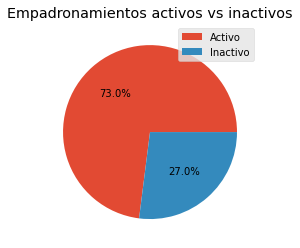

```python
data1=df_pdu["Estado"].value_counts()
plt.pie(data1,autopct='%1.1f%%')
plt.title("Empadronamientos activos vs inactivos")
plt.legend(['Activo', 'Inactivo'])
plt.show()
```

Para nuestro análisis solo vamos a trabajar con los **vehiculos activos** del parque automotor. Filtramos por estado y verificamos que la cantidad sea la correcta

```python
df_pdu_activos=df_pdu.loc[df_pdu['Estado'] == 'Activo']
df_pdu_activos.shape
```

```
(106772, 22)
```

```python
df_proc=df_pdu_activos["Procedencia"].value_counts().to_frame()
df_proc
```

|  | Procedencia |
| --- | --- |
| NUEVO | 93548 |
| REEMPADRONAMIENTO | 13098 |
| IMPORTACIÓN DIRECTA | 52 |
| DECOMISO DE ADUANA | 25 |
| MIGRADO/SIN DETERMINAR | 17 |
| RECONSTRUIDO | 9 |
| REMATE FF.AA. | 6 |
| JUZGADOS | 5 |
| REMATE JUDICIAL | 5 |
| REMATE PÚBLICO | 4 |
| ADMISIÓN TEMPORAL | 1 |
| REMATE POLICIAL | 1 |
| REMATE OFICIAL | 1 |

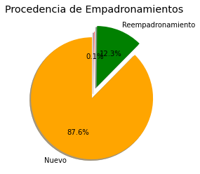

```python
df_pdu_act = df_pdu_activos.replace({'Procedencia':{'NUEVO':'NUEVO','REEMPADRONAMIENTO':'REEMPADRONAMIENTO','IMPORTACIÃ“N DIRECTA':'OTROS', 'REMATE PÃšBLICO':'OTROS',
                                                    'ADMISIÃ“N TEMPORAL':'OTROS','DECOMISO DE ADUANA':'OTROS','MIGRADO/SIN DETERMINAR':'OTROS','RECONSTRUIDO':'OTROS',
                                                   'REMATE FF.AA.':'OTROS','JUZGADOS':'OTROS','REMATE JUDICIAL':'OTROS','REMATE POLICIAL':'OTROS','REMATE OFICIAL':'OTROS'}})
data2=df_pdu_act['Procedencia'].value_counts()
plt.pie(data2,autopct='%1.1f%%',explode=(0.1,0.1,0),shadow=True, colors=['orange','green','red'],startangle=90, labels=['Nuevo', 'Reempadronamiento',''])
plt.title("Procedencia de Empadronamientos")
#plt.legend(['Nuevo', 'Reempadronamiento','Otros'])
plt.show()
```

Según el gráfico anterior el **87%** de los vehiculos activos han sido adquiridos en Paysandú y el **12%** reempadronados de otros departamentos

Se muestra en la tabla siguiente el origen de los vehiculos reempadronados

```python
df_pdu_act['Destino'].value_counts().to_frame()
```

|  | Destino |
| --- | --- |
| MONTEVIDEO | 1326 |
| SALTO | 896 |
| RIO NEGRO | 827 |
| COLONIA | 485 |
| MALDONADO | 458 |
| CANELONES | 391 |
| FLORES | 352 |
| SORIANO | 269 |
| TACUAREMBÓ | 258 |
| ARTIGAS | 253 |
| SAN JOSÉ | 246 |
| DURAZNO | 147 |
| RIVERA | 147 |
| FLORIDA | 102 |
| ROCHA | 58 |
| CERRO LARGO | 57 |
| TREINTA Y TRES | 49 |
| LAVALLEJA | 46 |
| PAYSANDÚ | 1 |

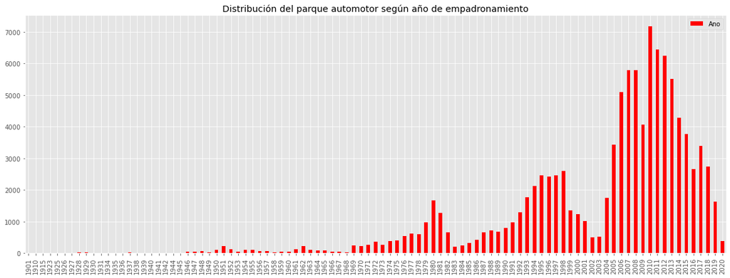

```python
indexNames1 = df_pdu_act[ (df_pdu_act['Ano'] == 110.0)].index
indexNames2 = df_pdu_act[ (df_pdu_act['Ano'] == 2398.0)].index
indexNames3 = df_pdu_act[ (df_pdu_act['Ano'] == 0.0)].index
df_pdu_act.drop(indexNames1 , inplace=True)
df_pdu_act.drop(indexNames2 , inplace=True)
df_pdu_act.drop(indexNames3 , inplace=True)
df_ano=df_pdu_act['Ano'].value_counts().to_frame().sort_index()
#df_ano.astype(int)
df_ano.index = df_ano.index.map(int)
df_ano.plot.bar(xlabel=None, color='r',figsize=(20,7),title="Distribución del parque automotor según año de empadronamiento")
```

Podemos concluir que actualmente la mayor cantidad de vehiculos del parque automotor fue empadronado en el año **2010** con una cantidad de **7177** vehículos.

```python
df_ano['Ano'].max() # Comprobamos valor
```

```
7177
```

```python
# install seaborn
# !pip3 install seaborn

# import library
import seaborn as sns

print('Seaborn importado e instalado')
```

```
Seaborn importado e instalado
```

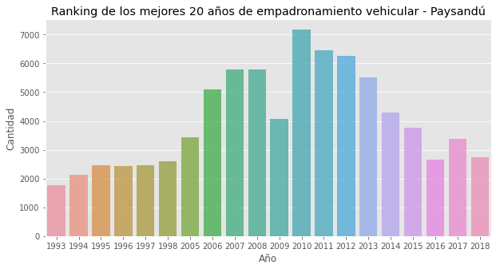

```python
x_ano=df_pdu_act['Ano'].value_counts(sort=True)
x_ano=x_ano.dropna(how='all')
x_ano=x_ano.head(n=20)
x_ano.index = x_ano.index.map(int)
x_ano
plt.figure(figsize=(10,5))
sns.barplot(x_ano.index, x_ano.values, alpha=0.8)
plt.title('Ranking de los mejores 20 años de empadronamiento vehicular - Paysandú')
plt.ylabel('Cantidad', fontsize=12)
plt.xlabel('Año', fontsize=12)
plt.show()
```

Con el gráfico anterior podemos concluir que el año 2010 fue el año con mayor empadronamientos en la ciudad de Paysandú. Por ende tambien implica que fue el año con mayor venta vehicular. Para validar esta información se anexa el siguiente link. [CLICK AQUÍ](https://www.180.com.uy/articulo/15162_Venta-de-autos-alcanzaria-cifra-record-en-2010)

```python
# Wordcloud
!pip3 install wordcloud==1.8.1
from wordcloud import WordCloud, STOPWORDS
print ('Wordcloud instalado!')
```

```
     |████████████████████████████████| 366 kB 30.0 MB/s
Wordcloud instalado!
```

```python
stopwords = set(STOPWORDS)
```

```python
import urllib.request
from PIL import Image
import warnings
warnings.filterwarnings('ignore')
```

```python
textito = " ".join(review for review in df_pdu_act.Marca.astype(str))
print ("Existen {} palabras combinadas en la columna Marcas.".format(len(textito)))
#excluyendo palabras (basura)
stopwords.update(["2017", "2019", "-----", "ACOPLADO", "1RF 66"," ", "CONTRUCCION NACIONAL","IND NACIONAL"])
```

```
Existen 768817 palabras combinadas en la columna Marcas.
```

```python
#auto_mask = np.array(Image.open(urlopen("https://raw.githubusercontent.com/monkodev/DataScience/main/auto_mask.png")))
auto_mask=np.array(urllib.request.urlretrieve("https://raw.githubusercontent.com/monkodev/DataScience/main/auto_mask.png","auto_mask.png"))
mas1=np.array(Image.open("auto_mask.png"))
```

```python
marcas_wc = WordCloud(
    background_color='white',
    max_words=2000,
    stopwords=stopwords,
    mask=mas1
)

# instanciando y generando el wordcloud de Marcas
marcas_wc.generate(textito)
```

```
<wordcloud.wordcloud.WordCloud at 0x7f7c0e3a9e90>
```

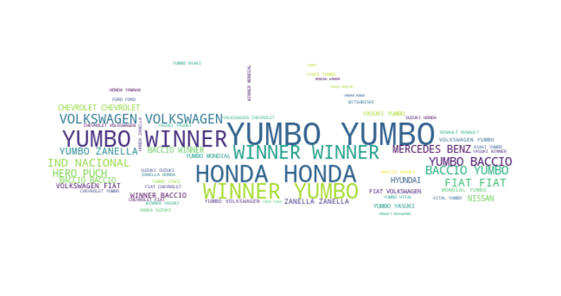

```python
fig = plt.figure(figsize=(14, 18))
plt.imshow(marcas_wc, interpolation='bilinear')
plt.axis('off')
plt.show()
```

Generamos el gráfico de nube (en forma de auto) para visualizar las marcas que más aparecen en la columna Marca. Se ve que las palabras *YUMBO, WINNER, HONDA, BACCIO* son las que se repiten con mayor frecuencia. **Concluimos que el parque automotor esta liderado en mayor proporcion por motos (birrodados)**